# Simulation for ddsPLS

# Simulation designs

The following repository gathers the simulated data-sets used to test the data-driven sparse partial least squares (**ddsPLS**) methodology. There are 3 simulation designs all of which follow a latent variable model

$$\begin{equation}
\left\{
\begin{array}{l}
\mathbf{x} = \mathbf{A}'\boldsymbol{\phi} + \boldsymbol{\epsilon} \text{ where } \mathbf{A}=[\mathbf{a}_{1},\cdots,\mathbf{a}_{\mathcal{R}}]'\in\mathcal{M}_{\mathcal{R}\times p}(\mathbb{R}) \text{ with } |\!|\mathbf{a}_{r}|\!| \neq 0, \\
\mathbf{y} = \mathbf{D}'\boldsymbol{\phi}+ \boldsymbol{\xi} \text{ where } \mathbf{D}=[\mathbf{d}_{1},\cdots,\mathbf{d}_{\mathcal{R}}]'\in\mathcal{M}_{\mathcal{R}\times q}(\mathbb{R}) \text{ with } |\!|\mathbf{d}_{r}|\!| \neq 0, \\
\text{with } \mbox{var} (\boldsymbol{\phi})=\mathbb{I}_\mathcal{R}
\text{, }\mathbb{E} \boldsymbol{\phi}=\mathbf{0}_\mathcal{R}\text{, }\mathbb{E} \boldsymbol{\epsilon}=\mathbf{0}_p\text{, }\mathbb{E} \boldsymbol{\xi}=\mathbf{0}_q,\\
\mbox{cov}(\boldsymbol{\phi},\boldsymbol{\epsilon})=\mathbf{0}_{\mathcal{R}\times q}\text{, }\mbox{cov}(\boldsymbol{\phi},\boldsymbol{\xi})=\mathbf{0}_{\mathcal{R}\times q}\text{, }\mbox{cov}(\boldsymbol{\epsilon},\boldsymbol{\xi})=\mathbf{0}_{p\times q}.
\end{array}
\right.
\label{equ:latencymodel_phi_prop2}
\end{equation}$$

Where $\boldsymbol{\phi}$ is a $\mathcal{R}$-dimensional random variable. It implies that $\mbox{var}(\mathbf{x})=\mathbf{A}'\mathbf{A} + \mbox{var}(\boldsymbol{\epsilon})$ and $\mbox{var}(\mathbf{y})=\mathbf{D}'\mathbf{D} + \mbox{var}(\boldsymbol{\xi})$ and $\mbox{cov}(\mathbf{y},\mathbf{x})=\mathbf{D}'\mathbf{A}$.

More precisely, each design is defined with different matrices **A** and **D** such as:

$$\begin{equation}
\begin{array}{c c c}
\mathbf{A} =\sqrt{1-\sigma^2}
\left(\begin{array}{ccc}
\alpha_3\boldsymbol{1}_{3,50} & \boldsymbol{0}_{3,50} & \boldsymbol{0}_{3,900}\\
\boldsymbol{0}_{2,50} & \alpha_2\boldsymbol{1}_{2,50} & \boldsymbol{0}_{2,900}\\
\end{array} \right)_{(5,1000)}
&\text{ and }&
\mathbf{D}=\sqrt{1-\sigma^2}
\left(\begin{array}{ccc}
\alpha_3\boldsymbol{1}_{3,1} & \boldsymbol{0}_{3,1} & \boldsymbol{0}_{3,1} \\
\boldsymbol{0}_{2,1} & \alpha_2\boldsymbol{1}_{2,1} & \boldsymbol{0}_{2,1} \\
\end{array} \right)_{(5,3)},
\end{array}
\label{equ:design_1}
\end{equation}$$

where $\forall k \in \mathbb{N}^\star, \ \alpha_k=1/\sqrt{k}$, $\sqrt{1-\sigma^2}=0.99$ and
$$\boldsymbol{\psi}=(\boldsymbol{\phi}',\boldsymbol{\epsilon}'_{1\dots100}/\sigma,
\boldsymbol{\epsilon}'_{101\dots1000},\boldsymbol{\xi}'_{1\dots2}/\sigma,\xi_{3})'\sim \mathcal{N}\left(\mathbf{0},\mathbb{I}_{5+1000+3}\right).$$

- **Design 2** corresponds to the concatenation of two blocks, $\mathbf{X}_1$ ($p_1=500$) corresponds to classical spectroscopy, $\mathbf{X}_2$ ($p_2=5000$) corresponds to Nuclear Magnetic Resonance (NMR) classical. Both of those blocks are based on $\mathcal{R}_t=10$ simulating different **spectra** ($\mathbf{S}_1$ and $\mathbf{S}_2$). The sampling randomness (equivalent of $\boldsymbol{\phi}$) is described by the **concentration** matrices ($\mathbf{C}_1$ and $\mathbf{C}_2$). In total the blocks follow the model
  $$\begin{equation}
  \mathbf{X}_t=
  \sqrt{1-\sigma_t^2}\mathbf{C}_t\mathbf{S}_t +
  \sigma_t\mathbf{E}_t
  \label{equ:design_3_x}
  \end{equation}$$
  which does not follow the model given in introduction since, among other things, the concentration matrices are not constrained to be of variance equal to the identity. The parameter $\sigma_t$ is the standard deviation of the additive noise and each row of $\mathbf{E}_t$ follows a white Gaussian multivariate ($p_t$-dimensional) law. The first five columns of $\mathbf{C}_2$ have been replaced by the first five columns of $\mathbf{C}_1$. The **Y** block ($q=5$) follows $\mathbf{Y}= \sqrt{1-\sigma_y^2}\mathbf{C}_y + \sigma_y\mathbf{E}_y$, where each row of $\mathbf{E}_y$ follows $\mathcal{N}(\mathbf{0},\mathbb{I})$, $\sigma_y=0.1$ and the three first columns of $\mathbf{C}_y$ (among five) are the three first columns of $\mathbf{C}_1$.

**N.B.**: In the submitted work, the `seed` parameter was fixed to the values `seed`$\in[\!1,100]\!]$, corresponding to the 100 analyzed datasets.

# Data Generation

To simulate from one of the three designs proposed before, a single file must be sourced:

```r
source("./functions.R")
```

In order to use the **ddsPLS** methodology, it must be installed, from GitHub for example **hlorenzo/ddsPLS2**

```r
  # install.packages("devtools")
  devtools::install_github("hlorenzo/ddsPLS2", build_vignettes = TRUE)
```

As you can notice, a **Vignette** is attached to the previous package and can be easily accessed using the command

```r
vignette("ddsPLS2")
```

## Toy Example

A simulation of the **Toy Example** is generated such as

```r
simu_toy <- get_toy_example(n=50,sqrt_1_minus_sig2 = 0.9025,p = 1000)
```

structure can be analyzed with the **ddsPLS** methodology

```r
library(ddsPLS2)
lambdas <- seq(0,1,length.out = 30) # to be tested lambda values
n_B <- 100 # number of bootstrap samples
model_toy <- ddsPLS(simu_toy$X,simu_toy$Y,
                   lambdas = lambdas,
                   n_B = n_B,
                   verbose = T # whether trace during process
                   )
```

```
##                       ______________
##                      |    ddsPLS    |
## =====================----------------=====================
## Should we build component 1 ? Bootstrap pending...
##      lambda   R2  R2h  Q2 Q2h VarExpl VarExpl.Tot
##        0.52 0.83 0.83 0.8 0.8     85%         85%
##                                      ...component 1 built!
## Should we build component 2 ? Bootstrap pending...
##      lambda   R2  R2h   Q2  Q2h VarExpl VarExpl.Tot
##           0 0.96 0.12 0.81 0.05     15%         99%
##                                      ...component 2 built!
## Should we build component 3 ? Bootstrap pending...
##                                  ...component 3 not built!
## =====================                =====================
##                      ================
```

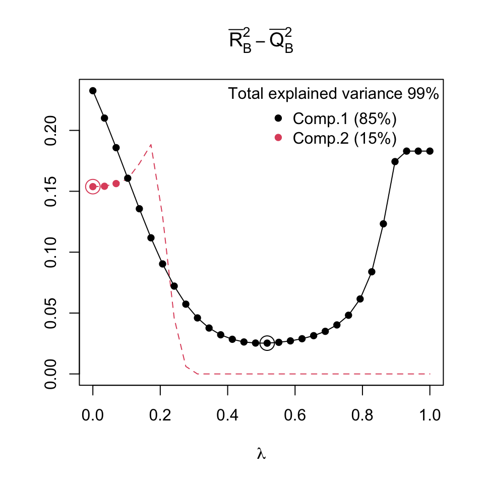

## Design 1

For this design it comes

```r
simu_1 <- get_design_1(n=50,sqrt_1_minus_sig2 = 0.99,p = 1000,q = 3)
```

and

```r
model_1 <- ddsPLS(simu_1$X,simu_1$Y,lambdas = lambdas,n_B=n_B,verbose=T)
```

```
##                       ______________
##                      |    ddsPLS    |
## =====================----------------=====================
## Should we build component 1 ? Bootstrap pending...
##      lambda   R2  R2h   Q2  Q2h VarExpl VarExpl.Tot
##        0.62 0.33 0.33 0.29 0.29     33%         33%
##                                      ...component 1 built!
## Should we build component 2 ? Bootstrap pending...
##      lambda   R2 R2h   Q2  Q2h VarExpl VarExpl.Tot
##        0.72 0.64 0.3 0.63 0.48     32%         65%
##                                      ...component 2 built!
## Should we build component 3 ? Bootstrap pending...
##                                  ...component 3 not built!
## =====================                =====================
##                      ================
```

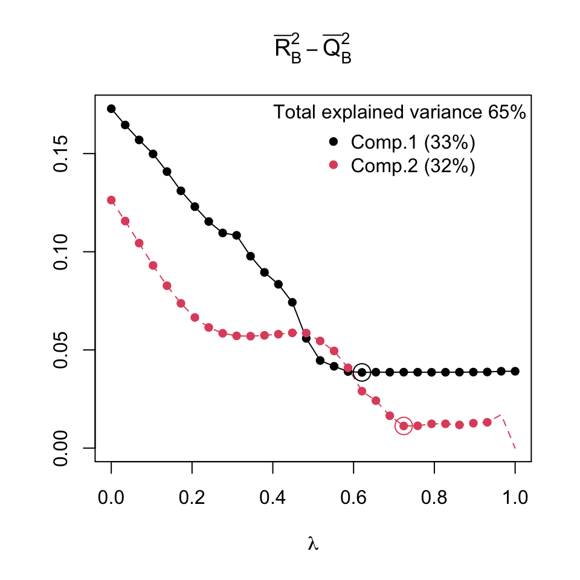

## Design 2

For this design it comes

```r
seed <- 1 # random seed to generate dataset
ncpX <- 10 # Number of latent variables in x blocks
ncpXCom <- 5 # Number of latent variables in common between x blocks
ncpXYCom <- 3 # Number of latent variables in common between y block and x blocks
simu_2 <- get_design_2(seed=seed,n=50,q=5,p1=500,p2=5000,
                       sigma1=0.05,sigma2=0.05,sigmaY = 0.1,
                       ncpX=ncpX,ncpXCom=ncpXCom,ncpXYCom=ncpXYCom)
```

and

```r
model_2 <- ddsPLS(do.call(cbind,simu_2$Xs),simu_2$Y,lambdas = lambdas,n_B=n_B,verbose=T)
```

```
##                       ______________
##                      |    ddsPLS    |
## =====================----------------=====================
## Should we build component 1 ? Bootstrap pending...
##      lambda  R2 R2h   Q2  Q2h VarExpl VarExpl.Tot
##        0.97 0.2 0.2 0.18 0.18     20%         20%
##                                      ...component 1 built!
## Should we build component 2 ? Bootstrap pending...
##      lambda   R2  R2h   Q2  Q2h VarExpl VarExpl.Tot
##        0.79 0.37 0.18 0.38 0.22     19%         39%
##                                      ...component 2 built!
## Should we build component 3 ? Bootstrap pending...
##      lambda   R2  R2h   Q2  Q2h VarExpl VarExpl.Tot
##        0.45 0.56 0.18 0.39 0.04     16%         55%
##                                      ...component 3 built!
## Should we build component 4 ? Bootstrap pending...
##                                  ...component 4 not built!
## =====================                =====================
##                      ================
```

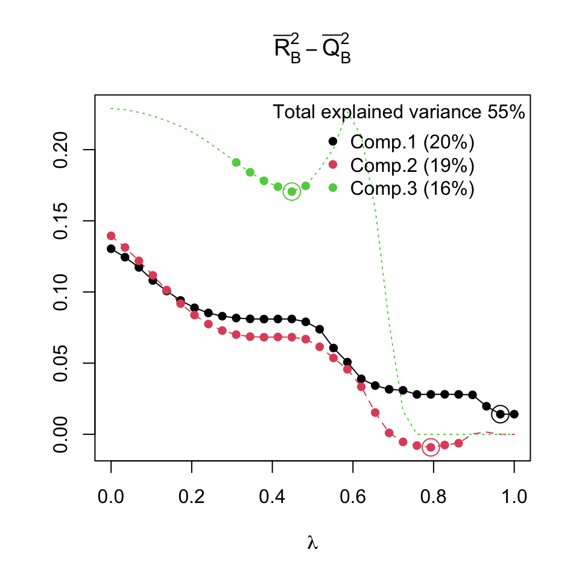